# Datasets

# Density Estimation

```python
from sklearn.mixture import GaussianMixture
```

## Temperature

### With 2 gaussians :

```python
Nb_gaussian = 2
```

```python
gm_temper = GaussianMixture(Nb_gaussian, covariance_type='diag')
gm_temper.fit(temper_data)
```

```
GaussianMixture(covariance_type='diag', n_components=2)
```

```python
means_temper = gm_temper.means_
weights_temper = gm_temper.weights_
covs_temper = gm_temper.covariances_
```

```python
def display_profiles_GMM(gm_temper, Nb_gaussian) :
    means_temper = gm_temper.means_
    weights_temper = gm_temper.weights_
    covs_temper = gm_temper.covariances_
    display_profiles(means_temper, labels = ["weight : " + str(w) for w in weights_temper])
    for i in range(Nb_gaussian) :
        if gm_temper.covariance_type == 'diag' or gm_temper.covariance_type == 'spherical' :
            std = np.sqrt(covs_temper[i])
        else :
            std = np.sqrt(covs_temper[i][i])
        plt.fill_between(temper_data.columns, means_temper[i] - std, means_temper[i] + std, alpha=0.5*weights_temper[i])
    plt.legend()
```

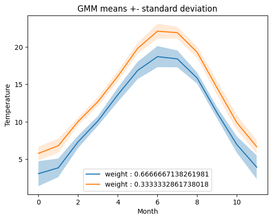

```python
plt.figure()
display_profiles_GMM(gm_temper, Nb_gaussian)
plt.title("GMM means +- standard deviation")
plt.show()
```

Here as in kmeans the gaussians seems to represent two principal groups of points : the southern/hot cities and the center-northern/cold cities. Also the weight of the gaussians seems to correspond to the number of cities within each group.

```python
distrib_temper = np.exp(gm_temper.score_samples(temper_data))
distrib_temper
```

```
array([3.98886927e-06, 4.82912689e-14, 2.90512407e-06, 1.04960975e-07,
       1.10279391e-09, 9.77786764e-09, 2.21330841e-06, 4.87014345e-05,
       3.36193777e-08, 1.62114398e-09, 1.99266980e-06, 3.10059395e-07,
       4.25403251e-11, 4.64161630e-10, 3.26798800e-06])
```

### With other numbers of clusters

```python
def generate_GMMs(Nb_gaussian_test, cov_type) :
    gm_tempers = []
    for nb_gaussian in Nb_gaussian_test :
        gm_temper_temp = GaussianMixture(nb_gaussian, covariance_type= cov_type, random_state=42)
        gm_temper_temp.fit(temper_data)
        gm_tempers.append(gm_temper_temp)
    return gm_tempers
```

```python
Nb_gaussians_test = [2, 3, 4, 5, 7, 10]

diag_gmms = generate_GMMs(Nb_gaussians_test, 'diag')
```

```python
def display_gmms(gmms, Nb_gaussians_test, cols = temper_data.columns, size = [2,3]) :

    fig, axs = plt.subplots(size[0],size[1], figsize = (20,size[0]*6))

    for i in range(len(Nb_gaussians_test)):

        gm_temp =  gmms[i]
        means_temper = gm_temp.means_
        weights_temper = gm_temp.weights_
        covs_temper = gm_temp.covariances_

        for j in range(len(means_temper)) :

            if size[0] > 1 :
                a = axs[i//3, i%3]
            else :
                a = axs[i]

            ## Plot Mean of Gaussian
            a.plot(cols, means_temper[j], label = "weight : " + str(weights_temper[j]))

            ## Plot Standard Deviation Interval
            if gm_temp.covariance_type == 'diag' or gm_temp.covariance_type == 'spherical' :
                std = np.sqrt(covs_temper[j])
            else :
                std = np.sqrt(covs_temper[j][j])
            a.fill_between(temper_data.columns, means_temper[j] - std, means_temper[j] + std, alpha=0.5*weights_temper[j])

        a.set_ylabel("Temperature")
        a.set_xlabel("Month")
        a.set_title(f"K = {Nb_gaussians_test[i]}, {gm_temper.covariance_type} covariance")
        a.legend()

    plt.tight_layout(pad=2.0)
    plt.suptitle("GMM Means +- Standard Deviation (Opacity ~ Weight) for Different Values of K", fontsize = 20, y=1.03 )
```

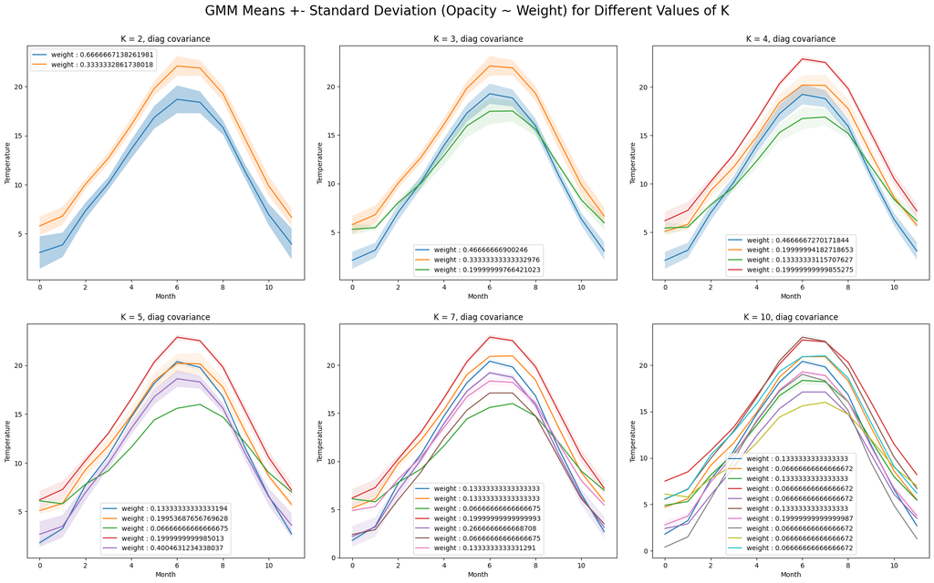

```python
display_gmms(diag_gmms, Nb_gaussians_test)

plt.show()
```

From a number of 5 gaussian distributions, some of them seems negligible (since their weight is less than 10% or their center/ standard deviation seems to be redundant). Since then we consider the best number of gaussians is 4

Now let's try for different forms of covariance matrices

[figure not shown]

```python
Nb_gaussians_covs = [4, 4, 4]

n = [Nb_gaussians_covs[0]]

full_gmms = generate_GMMs(n, 'full')
tied_gmms = generate_GMMs(n, 'tied')
shperical_gmms = generate_GMMs(n, 'spherical')
gmms_covs = np.concatenate([full_gmms, tied_gmms, shperical_gmms])

display_gmms(gmms_covs, Nb_gaussians_covs, size = [1,3])
plt.show()
```

Since the covariance type don't change much the gaussian distributions and their weights we choose the simplest and less demanding in computation costs : the diagonal covariance matrix

```python
temper_gmm = diag_gmms[2]
```

```python
temper_scores = temper_gmm.score_samples(temper_data)
temper_scores
```

```
array([-15.80161415, -10.0356526 , -10.09286192, -12.17301471,
       -22.16423484, -15.19958636,  -6.79424244,  -8.20735739,
       -16.13786758, -10.45876658, -13.48102508, -10.03565296,
       -22.45816141,  -9.45546145,  -9.45209303])
```